# HazReg: Parametric Excess Hazard-based regression models for survival data

[F. Javier Rubio](https://sites.google.com/site/fjavierrubio67/)

04 November, 2026

# Models

The `HazReg` R package implements the following parametric excess hazard-based regression models for (relative) survival data.

- General Hazard (GH) model (Chen and Jewell 2001) (Rubio et al. 2019).
- Accelerated Failure Time (AFT) model (Kalbfleisch and Prentice 2011).
- Proportional Hazards (PH) model (Cox 1972).
- Accelerated Hazards (AH) model (Chen and Wang 2000).

These models are fitted using the R commands `nlminb` and `optim`. Thus, the user needs to specify the initial points and to check the convergence of the optimisation step, as usual.

A description of these excess hazard models is presented below as well as the available baseline hazards. See also Rubio et al. (2019).

## Relative survival

In the relative survival framework, the idea is to decompose the individual hazard of death function, $h(\cdot)$, into two parts: the hazard associated to cancer (excess hazard), $h_E(\cdot)$, and the hazard associated to other causes of death, $h_O(\cdot)$: (Pohar-Perme, Stare, and Estève 2012) (Eletti et al. 2022):

$$h(t \mid{\bf x}) = h_E(t\mid{\bf x}) + h_O(\text{age} + t),$$
where $\text{age}$ is the age at diagnosis of cancer, and ${\bf x}\in{\mathbb R}^p$ are the available patient/tumour characteristics (covariates). The decomposition of the hazard function makes the relative survival framework fundamentally different from the overall survival framework. The hazard associated to other causes of death, $h_O(t)$, is typically estimated with the population hazard function $h_P(\text{age}+t\mid {\bf w})$, which is obtained from life tables based on available characteristics denoted by the vector ${\bf w} \in {\mathbb R}^q \subset {\bf x}$. Thus, an additional difference with the overall survival framework is the incorporation of external information coming from the life tables.

## General Excess Hazard model

The GH model is formulated in terms of the hazard structure
$$h_E(t; \alpha, \beta, \theta, {\bf x}) = h_0\left(t \exp\{\tilde{\bf
x}^{\top}\alpha\}; \theta\right) \exp\{{\bf x}^{\top}\beta\}.$$
where ${\bf x}\in{\mathbb R}^p$ are the covariates that affect the hazard level; $\tilde{\bf x} \in {\mathbb R}^q$ are the covariates the affect the time level (typically $\tilde{\bf x} \subset {\bf x}$); $\alpha \in {\mathbb R}^q$ and $\beta \in {\mathbb R}^p$ are the regression coefficients; and $\theta \in \Theta$ is the vector of parameters of the baseline hazard $h_0(\cdot)$.

This hazard structure leads to an identifiable model as long as the baseline hazard is not a hazard associated to a member of the Weibull family of distributions (Chen and Jewell 2001).

## Accelerated Failure Time (AFT) model

The AFT model is formulated in terms of the hazard structure
$$h_E(t; \beta, \theta, {\bf x}) = h_0\left(t \exp\{{\bf
x}^{\top}\beta\}; \theta\right) \exp\{{\bf x}^{\top}\beta\}.$$
where ${\bf x}\in{\mathbb R}^p$ are the available covariates; $\beta \in {\mathbb R}^p$ are the regression coefficients; and $\theta \in \Theta$ is the vector of parameters of the baseline hazard $h_0(\cdot)$.

## Proportional Hazards (PH) model

The PH model is formulated in terms of the hazard structure
$$h_E(t; \beta, \theta, {\bf x}) = h_0\left(t ; \theta\right) \exp\{{\bf
x}^{\top}\beta\}.$$
where ${\bf x}\in{\mathbb R}^p$ are the available covariates; $\beta \in {\mathbb R}^p$ are the regression coefficients; and $\theta \in \Theta$ is the vector of parameters of the baseline hazard $h_0(\cdot)$.

## Accelerated Hazards (AH) model

The AH model is formulated in terms of the hazard structure
$$h_E(t; \alpha, \theta, \tilde{\bf x}) = h_0\left(t \exp\{\tilde{\bf
x}^{\top}\alpha\}; \theta\right) .$$
where $\tilde{\bf x}\in{\mathbb R}^q$ are the available covariates; $\alpha \in {\mathbb R}^q$ are the regression coefficients; and $\theta \in \Theta$ is the vector of parameters of the baseline hazard $h_0(\cdot)$.

# Available baseline hazards

The current version of the `HazReg` R package implements the following parametric baseline excess hazards for the models discussed in the previous section.

- [Power Generalised Weibull](http://rpubs.com/FJRubio/PGW) (PGW) distribution.
- [Exponentiated Weibull](http://rpubs.com/FJRubio/EWD) (EW) distribution.
- [Generalised Gamma](http://rpubs.com/FJRubio/GG) (GG) distribuiton.
- [Gamma](https://en.wikipedia.org/wiki/Gamma_distribution) (G) distribution.
- [Lognormal](https://en.wikipedia.org/wiki/Log-normal_distribution) (LN) distribution.
- [Log-logistic](https://en.wikipedia.org/wiki/Log-logistic_distribution) (LL) distribution.
- [Weibull](https://en.wikipedia.org/wiki/Weibull_distribution) (W) distribution. (only for AFT, PH, and AH models)

All positive parameters are transformed into the real line using a `log` reparameterisation.

# Illustrative example: R code

In this example, we analyse a simulated data set. This data set contains information about the survival of 10,000 patients.

For the GH model, we consider the hazard level covariates (${\bf x}$) age (centred), sex, treatment (trt); and the same time level covariates (${\bf x}$).

For illustration, we fit the 4 models with both (3-parameter) PGW and (2-parameter) LL baseline hazard. In addition, we fit the GH model with GG, EW, LN, and G baseline hazards. We compare these models in terms of AIC (BIC can be used as well). We summarise the best selected model with the available tools in this package.

See also: GHSurv, LBANS

## Data preparation

```r
rm(list=ls())

# Required packages
#library(devtools)
#install_github("FJRubio67/HazReg")
library(HazReg)
library(numDeriv)
library(knitr)
library(survival)
library(mvtnorm)
library(matrixStats)

# Load the simulated data set
# https://github.com/FJRubio67/HazReg
df <- as.data.frame(read.table("dataGH.txt"))
colnames(df)
```

```
## [1] "agec"      "sex"       "TTT"       "surv.time" "status"    "rate"
```

```r
dim(df)
```

```
## [1] 10000     6
```

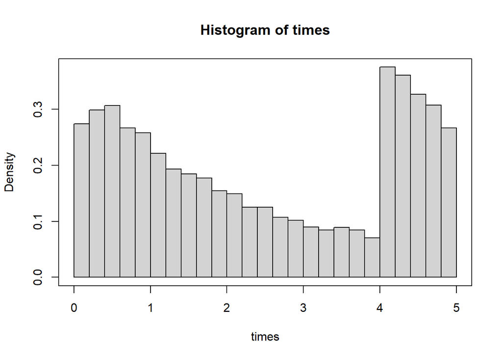

```r
# Design matrix for hazard level effects
X <- as.matrix(cbind( df$agec, df$sex, df$TTT ))
colnames(X) <- cbind("std age", "sex", "trt")

# Design matrix for time level effects
Xt <- as.matrix(X)

q <- dim(Xt)[2]
p <- dim(X)[2]


# Vital status
status <- as.vector(df$status)

# Survival times
times <- as.vector(df$surv.time) # in years

# Population hazard rates for all individuals
hp <- df$rate

# Histogram of survival times
hist(times, probability = TRUE, breaks = 30)
box()
```

## Model fit and MLEs

```r
# PGWGH
OPTPGWGH <- GEHMLE(init = rep(0, 3 + ncol(X) + ncol(Xt)), times = times, status = status, hp = hp,
                   hstr = "GH", dist = "PGW", des = X, des_t = Xt, method = "nlminb", control = list(iter.max = 10000))

# PGWAFT
OPTPGWAFT <- GEHMLE(init = rep(0, 3 + ncol(X)), times = times, status = status, hp = hp,
                    hstr = "AFT", dist = "PGW", des = X, method = "nlminb", control = list(iter.max = 10000))

# PGWPH
OPTPGWPH <- GEHMLE(init = rep(0, 3 + ncol(X)), times = times, status = status, hp = hp,
                   hstr = "PH", dist = "PGW", des = X, method = "nlminb", control = list(iter.max = 10000))

# PGWAH
OPTPGWAH <- GEHMLE(init = rep(0, 3 + ncol(X)), times = times, status = status, hp = hp,
                   hstr = "AH", dist = "PGW", des_t = X, method = "nlminb", control = list(iter.max = 10000))


# LLGH
OPTLLGH <- GEHMLE(init = rep(0, 2 + ncol(X) + ncol(Xt)), times = times, status = status, hp = hp,
                 hstr = "GH", dist = "LogLogistic", des = X, des_t = Xt, method = "nlminb", control = list(iter.max = 10000))

# LLAFT
OPTLLAFT <- GEHMLE(init = rep(0, 2 + ncol(X)), times = times, status = status, hp = hp,
                  hstr = "AFT", dist = "LogLogistic", des = X, method = "nlminb", control = list(iter.max = 10000))

# LLPH
OPTLLPH <- GEHMLE(init = rep(0, 2 + ncol(X)), times = times, status = status, hp = hp,
                 hstr = "PH", dist = "LogLogistic", des = X, method = "nlminb", control = list(iter.max = 10000))

# LLAH
OPTLLAH <- GEHMLE(init = rep(0, 2 + ncol(X)), times = times, status = status, hp = hp,
                 hstr = "AH", dist = "LogLogistic", des_t = X, method = "nlminb", control = list(iter.max = 10000))


# EWGH
OPTEWGH <- GEHMLE(init = rep(0, 3 + ncol(X) + ncol(Xt)), times = times, status = status, hp = hp,
                 hstr = "GH", dist = "EW", des = X, des_t = Xt, method = "nlminb", control = list(iter.max = 10000))
# GGGH
OPTGGGH <- GEHMLE(init = rep(0, 3 + ncol(X) + ncol(Xt)), times = times, status = status, hp = hp,
                 hstr = "GH", dist = "GenGamma", des = X, des_t = Xt, method = "nlminb", control = list(iter.max = 10000))

# LNGH
OPTLNGH <- GEHMLE(init = rep(0, 2 + ncol(X) + ncol(Xt)), times = times, status = status, hp = hp,
                 hstr = "GH", dist = "LogNormal", des = X, des_t = Xt, method = "nlminb", control = list(iter.max = 10000))

# GGH
OPTGGH <- GEHMLE(init = rep(0, 2 + ncol(X) + ncol(Xt)), times = times, status = status, hp = hp,
               hstr = "GH", dist = "Gamma", des = X, des_t = Xt, method = "nlminb", control = list(iter.max = 10000))

# MLEs in the original parameterisations
MLEPGWGH <- c(exp(OPTPGWGH$OPT$par[1:3]),OPTPGWGH$OPT$par[-c(1:3)])
MLEEWGH <- c(exp(OPTEWGH$OPT$par[1:3]),OPTEWGH$OPT$par[-c(1:3)])
MLEGGGH <- c(exp(OPTGGGH$OPT$par[1:3]),OPTGGGH$OPT$par[-c(1:3)])
MLEGGH <- c(exp(OPTGGH$OPT$par[1:2]),OPTGGH$OPT$par[-c(1:2)])
MLELNGH <- c(OPTLNGH$OPT$par[1], exp(OPTLNGH$OPT$par[2]), OPTLNGH$OPT$par[-c(1,2)])
MLELLGH <- c(OPTLLGH$OPT$par[1], exp(OPTLLGH$OPT$par[2]), OPTLLGH$OPT$par[-c(1,2)])

MLES <- cbind(MLEPGWGH, MLEEWGH, MLEGGGH, c(MLEGGH[1:2], NA, MLEGGH[-(1:2)]),
              c(MLELNGH[1:2], NA, MLELNGH[-(1:2)]), c(MLELLGH[1:2], NA, MLELLGH[-(1:2)]))
colnames(MLES) <- c("PGWGH", "EWGH", "GGGH", "GGH", "LNGH", "LLGH")
rownames(MLES) <- c("theta[1]","theta[2]","theta[3]","age_t", "sex_t", "trt_t","age", "sex", "trt")

# MLEs for GH models
kable(MLES, digits = 3)
```

|  | PGWGH | EWGH | GGGH | GGH | LNGH | LLGH |
| --- | --- | --- | --- | --- | --- | --- |
| theta[1] | 1.717 | 1.817 | 0.510 | 1.157 | 1.170 | 1.118 |
| theta[2] | 1.285 | 0.618 | 1.526 | 3.641 | 1.426 | 0.775 |
| theta[3] | 2.120 | 2.374 | 0.527 | NA | NA | NA |
| age_t | 0.095 | 0.094 | 0.094 | 0.244 | 0.054 | 0.068 |
| sex_t | 0.063 | 0.041 | 0.043 | 0.627 | -0.157 | -0.090 |
| trt_t | 0.023 | -0.008 | -0.019 | 0.593 | -0.165 | -0.086 |
| age | 0.048 | 0.048 | 0.048 | 0.029 | 0.055 | 0.052 |
| sex | 0.143 | 0.143 | 0.144 | 0.110 | 0.128 | 0.141 |
| trt | 0.268 | 0.268 | 0.268 | 0.236 | 0.259 | 0.270 |

## Model Comparison

```r
# AIC for models with PGW baseline hazard
AICPGWGH <- 2*OPTPGWGH$OPT$objective + 2*length(OPTPGWGH$OPT$par)
AICPGWAFT <- 2*OPTPGWAFT$OPT$objective + 2*length(OPTPGWAFT$OPT$par)
AICPGWPH <- 2*OPTPGWPH$OPT$objective + 2*length(OPTPGWPH$OPT$par)
AICPGWAH <- 2*OPTPGWAH$OPT$objective + 2*length(OPTPGWAH$OPT$par)

# AICs for models with LL baseline hazard
AICLLGH <- 2*OPTLLGH$OPT$objective + 2*length(OPTLLGH$OPT$par)
AICLLAFT <- 2*OPTLLAFT$OPT$objective + 2*length(OPTLLAFT$OPT$par)
AICLLPH <- 2*OPTLLPH$OPT$objective + 2*length(OPTLLPH$OPT$par)
AICLLAH <- 2*OPTLLAH$OPT$objective + 2*length(OPTLLAH$OPT$par)

# AICs for GH models with GG, EW, LN, and G hazards
AICGGGH <- 2*OPTGGGH$OPT$objective + 2*length(OPTGGGH$OPT$par)
AICEWGH <- 2*OPTEWGH$OPT$objective + 2*length(OPTEWGH$OPT$par)
AICLNGH <- 2*OPTLNGH$OPT$objective + 2*length(OPTLNGH$OPT$par)
AICGGH <- 2*OPTGGH$OPT$objective + 2*length(OPTGGH$OPT$par)



# All AICs
AICs <- c(AICPGWGH, AICPGWAFT, AICPGWPH, AICPGWAH,
          AICLLGH, AICLLAFT, AICLLPH, AICLLAH,
          AICGGGH, AICEWGH, AICLNGH, AICGGH)

round(AICs, digits = 2)
```

```
##  [1] 26138.55 26157.89 26221.30 26301.88 26154.98 26174.40 26231.78 26918.02
##  [9] 26138.36 26137.60 26246.92 26203.79
```

```r
# Best model: EWGH
which.min(AICs)
```

```
## [1] 10
```

## Baseline hazards for GH models

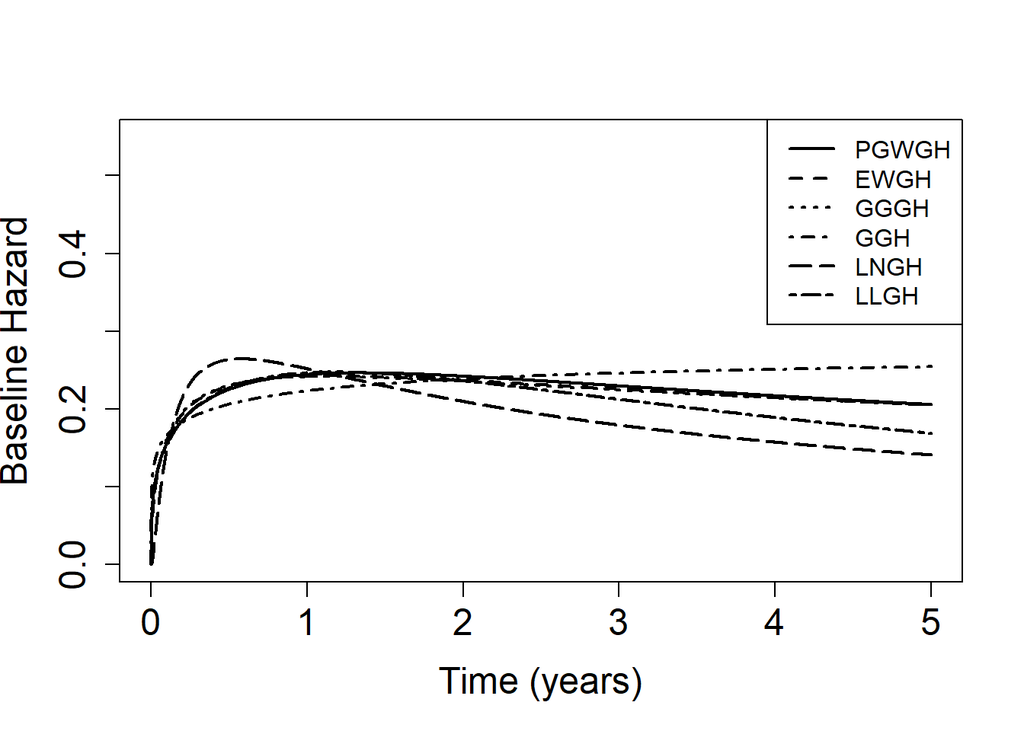

```r
# Fitted baseline hazard functions for GH models
PGWGHhaz <- Vectorize(function(t) hpgw(t, MLEPGWGH[1], MLEPGWGH[2], MLEPGWGH[3]) )
EWGHhaz <- Vectorize(function(t) hew(t, MLEEWGH[1], MLEEWGH[2], MLEEWGH[3]) )
GGGHhaz <- Vectorize(function(t) hggamma(t, MLEGGGH[1], MLEGGGH[2], MLEGGGH[3]) )
GGHhaz <- Vectorize(function(t) hgamma(t, MLEGGH[1], MLEGGH[2]) )
LNGHhaz <- Vectorize(function(t) hlnorm(t, MLELNGH[1], MLELNGH[2]))
LLGHhaz <- Vectorize(function(t) hllogis(t, MLELLGH[1], MLELLGH[2]))

# Note that the baseline hazards associated to the top models look similar
curve(PGWGHhaz,1e-6, max(times), xlab = "Time (years)", ylab = "Baseline Hazard", main = "",
      cex.axis = 1.5, cex.lab = 1.5, lwd = 2, ylim = c(0,0.55), n = 1000)
curve(EWGHhaz,1e-6, max(times), lwd = 2, n = 1000, lty = 2, add = TRUE)
curve(GGGHhaz,1e-6, max(times), lwd = 2, n = 1000, lty = 3, add = TRUE)
curve(GGHhaz,1e-6, max(times), lwd = 2, n = 1000, lty = 4, add = TRUE)
curve(LNGHhaz,1e-6, max(times), lwd = 2, n = 1000, lty = 5, add = TRUE)
curve(LLGHhaz,1e-6, max(times), lwd = 2, n = 1000, lty = 6, add = TRUE)
legend("topright", legend = c("PGWGH", "EWGH", "GGGH", "GGH", "LNGH", "LLGH"), lwd = rep(2,6), lty = 1:6)
```

## Best-model summaries

```r
# MLE in the original parameterisation
MLE <- c(exp(OPTEWGH$OPT$par[1:3]),OPTEWGH$OPT$par[-c(1:3)])

round(MLE, digits = 3)
```

```
## [1]  1.817  0.618  2.374  0.094  0.041 -0.008  0.048  0.143  0.268
```

```r
# 95% Confidence intervals under the reparameterisation
CI <- Conf_Int(FUN = OPTEWGH$log_lik, MLE = OPTEWGH$OPT$par, level = 0.95)
rownames(CI) <- c("theta[1]","theta[2]","theta[3]","age_t", "sex_t", "trt_t","age", "sex", "trt")

kable(CI, digits = 3)
```

|  | Lower | Upper | Transf MLE | Std. Error |
| --- | --- | --- | --- | --- |
| theta[1] | 0.274 | 0.920 | 0.597 | 0.165 |
| theta[2] | -0.633 | -0.329 | -0.481 | 0.077 |
| theta[3] | 0.621 | 1.108 | 0.865 | 0.124 |
| age_t | 0.074 | 0.114 | 0.094 | 0.010 |
| sex_t | -0.286 | 0.368 | 0.041 | 0.167 |
| trt_t | -0.332 | 0.316 | -0.008 | 0.165 |
| age | 0.044 | 0.052 | 0.048 | 0.002 |
| sex | 0.088 | 0.199 | 0.143 | 0.028 |
| trt | 0.212 | 0.324 | 0.268 | 0.029 |

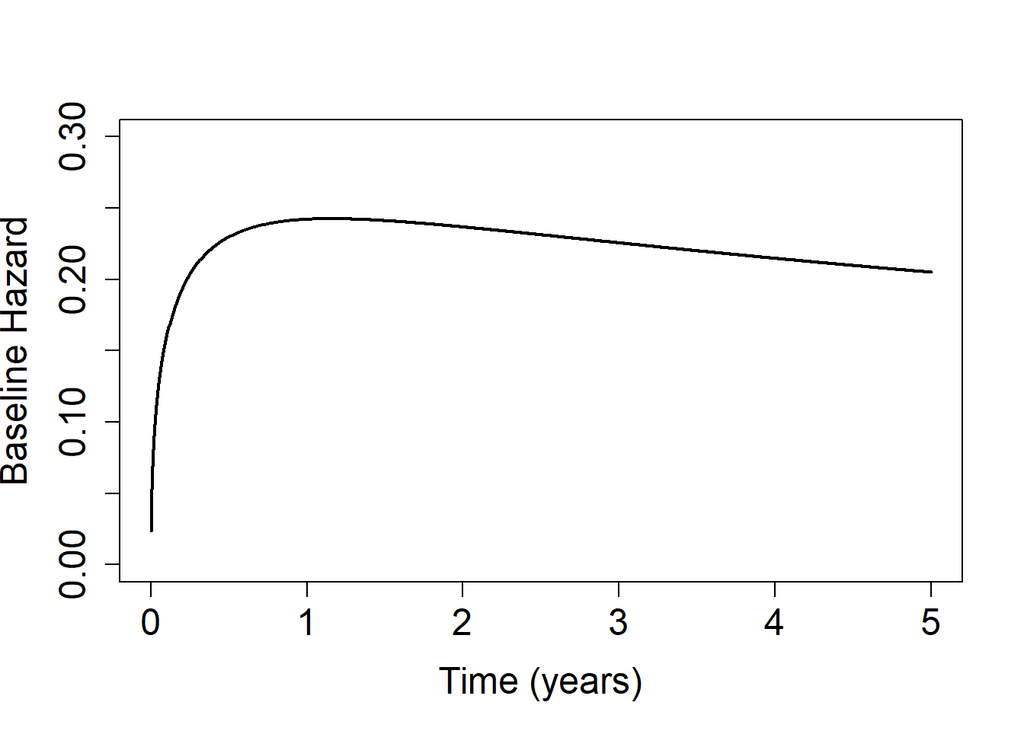

```r
# Fitted baseline hazard function
fit_haz <- Vectorize(function(t) hew(t, MLE[1], MLE[2], MLE[3]))

curve(fit_haz,0.001, max(times), xlab = "Time (years)", ylab = "Baseline Hazard", main = "",
      cex.axis = 1.5, cex.lab = 1.5, lwd = 2, ylim = c(0,0.3), n = 1000)
```

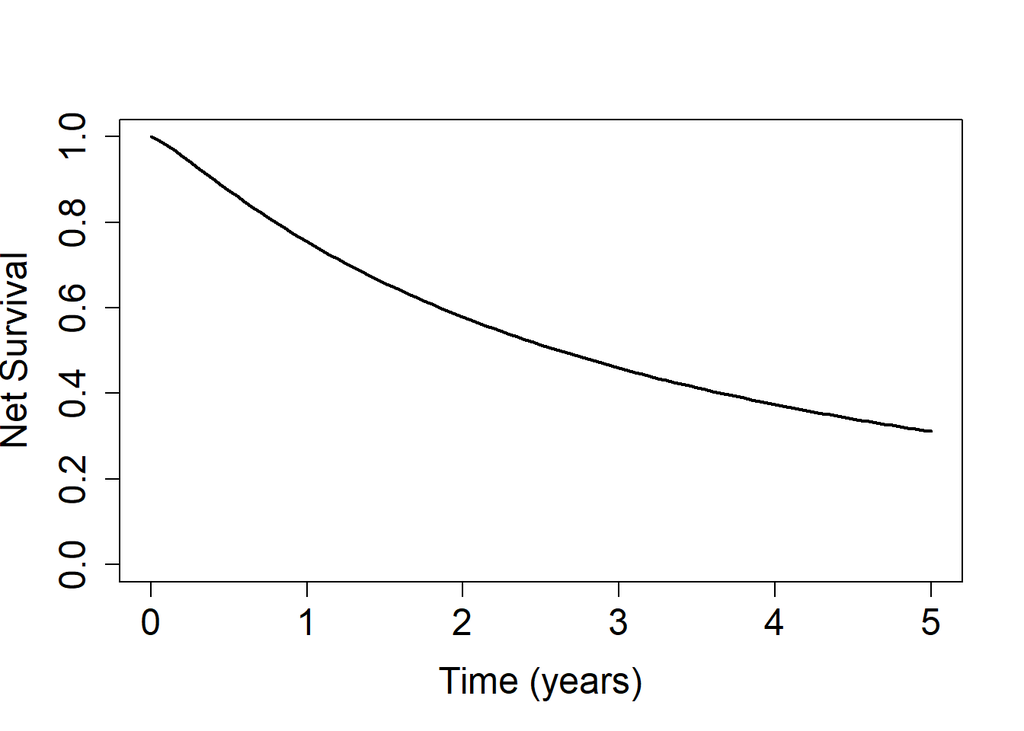

```r
# Average population net survival function

  p0 <- dim(Xt)[2]
  p1 <- dim(X)[2]
  theta1 <- MLE[1]; theta2 <- MLE[2]; theta3 <- MLE[3]; alpha <- MLE[4:(3+p0)]; beta <- MLE[(4+p0):(3+p0+p1)]
  x.alpha <- Xt%*%alpha
  x.dif <- X%*%beta - x.alpha

net_surv <- Vectorize(function(t){
  out <- mean( exp( - chew(t*exp(x.alpha), theta1, theta2, theta3)*exp(x.dif)  )  )
  return(out)
})


# Comparison
curve(net_surv,0.001,5, type = "l", col = "black", lwd = 2, lty = 1, ylim = c(0,1),
     xlab = "Time (years)", ylab = "Net Survival", main = "",
     cex.axis = 1.5, cex.lab = 1.5)
```

```r
# Confidence intervals for the net survival function based on a normal approximation
# at specific time points t0

# Hessian and asymptotic covariance matrix
HESS <- hessian(func = OPTEWGH$log_lik, x = OPTEWGH$OPT$par)
Sigma <- solve(HESS)

# Reparameterised MLE
r.MLE <- OPTEWGH$OPT$par

# The function to obtain approximate CIs based on Monte Carlo simulations
# from the asymptotic normal distribution of the MLEs
# t0 : time where the confidence interval will be calculated
# level : confidence level
# n.mc : number of Monte Carlo iterations

conf.int.nsurv <- function(t0, level, n.mc){
  mc <- vector()
  S.par <- function(par){ mean( exp( - chew(t0*exp(Xt%*%par[4:(3+p0)]), par[1], par[2], par[3])*
                                      exp(X%*%par[(4+p0):(3+p0+p1)]-Xt%*%par[4:(3+p0)])  )  )
  }

  for(i in 1:n.mc) {
    val <- rmvnorm(1,mean = r.MLE, sigma = Sigma)
    val[1:3] <- exp(val[1:3])
    mc[i] <- S.par(val)
  }

  L <- quantile(mc,(1-level)*0.5)
  U <- quantile(mc,(1+level)*0.5)

  M <- S.par(MLE)

  return(c(L,M,U))
}


# times for CIs calculations
timesCI <- c(1,2,3,4,5)

CIS <- matrix(0, ncol = 4, nrow = length(timesCI))

for(k in 1:length(timesCI)) CIS[k,] <- c(timesCI[k],conf.int.nsurv(timesCI[k],0.95,10000))

colnames(CIS) <- cbind("year","lower","net survival","upper")
print(kable(CIS,digits=4))
```

```
##
##
## | year|  lower| net survival|  upper|
## |----:|------:|------------:|------:|
## |    1| 0.7485|       0.7551| 0.7649|
## |    2| 0.5716|       0.5791| 0.5915|
## |    3| 0.4519|       0.4595| 0.4720|
## |    4| 0.3667|       0.3743| 0.3873|
## |    5| 0.3032|       0.3113| 0.3249|
```

Chen, Y. Q., and N. P. Jewell. 2001. “On a General Class of Semiparametric Hazards Regression Models.” *Biometrika* 88 (3): 687–702.

Chen, Y. Q., and M. C. Wang. 2000. “Analysis of Accelerated Hazards Models.” *Journal of the American Statistical Association* 95 (450): 608–18.

Cox, D. R. 1972. “Regression Models and Life-Tables.” *Journal of the Royal Statistical Society: Series B (Methodological)* 34 (2): 187–202.

Eletti, A., G. Marra, M. Quaresma, R. Radice, and F. J. Rubio. 2022. “A Unifying Framework for Flexible Excess Hazard Modelling with Applications in Cancer Epidemiology.” *Journal of the Royal Statistical Society - Series C* 71: 1044–62.

Kalbfleisch, J. D., and R. L. Prentice. 2011. *The Statistical Analysis of Failure Time Data*. John Wiley & Sons.

Pohar-Perme, M., J. Stare, and J. Estève. 2012. “On Estimation in Relative Survival.” *Biometrics* 68: 113–20.

Rubio, F. J., L. Remontet, N. P. Jewell, and A. Belot. 2019. “On a General Structure for Hazard-Based Regression Models: An Application to Population-Based Cancer Research.” *Statistical Methods in Medical Research* 28: 2404–17.